# Design Simulation Study

Marta Bofill Roig and Guadalupe Gomez Melis

2020-09-27

## Goal

We design a simulation study for survival and binary data, according to two different cases:

- Under Cox proportional hazards (PH) model
- Under Cox non-proportional hazards (non-PH) model

## Under PH model

### Univariate simulation (only survival data)

We follow the techniques presented in:

- Bender R, Augustin T, Blettner M. *Generating survival times to simulate Cox proportional hazards models*. Statistics in Medicine. 2005.

Therefore, if $T_0 \sim Weibull(a,b)$, then to obtain PH between groups according to HR we should simulate
$$T_1 \sim \left( -\frac{\log(U)}{(1/b)^a*HR} \right)^{1/a}$$
Here $U$ is a variable following a uniform distribution on the interval from 0 to 1. Note that if we replace $HR$ with $1$, we simulate $Weibull(a,b)$.

#### Example

Control group:

```r
a=2;b=2;tau=2;n0=1000;n1=1000;HR=0.75;H0=F

TE0 = rweibull(n0,a,b)
TC0 = runif(n1,0,tau)
time0 = ifelse(TE0<=TC0,TE0,TC0)
status0 = ifelse(TE0<=TC0 & TE0<tau,1,0)
treat0 = rep(0,n1)
sim0 <- data.frame(time0,status0,treat0)
```

Treatment group:

```r
if(H0==TRUE){
  TE1 = rweibull(n1,a,b)
}else{
  lambda=(1/b)^a
  rho=a
  v <- runif(n=n1)
  TE1 <- (- log(v)/(lambda*HR))^(1/rho)
}

TC1 = runif(n1, 0,tau)
time1 = ifelse(TE1<=TC1,TE1,TC1)
status1 = ifelse(TE1<=TC1 & TE1<tau,1,0)
treat1 = rep(1,n1)

sim1 <- data.frame(time1,status1,treat1)
```

Two-sample data:

```r
data = data.frame(time=c(sim1$time1,sim0$time0),
                  status=c(sim1$status1,sim0$status0),
                  treat=c(sim1$treat1,sim0$treat0))
```

Kaplan-Meier curves:

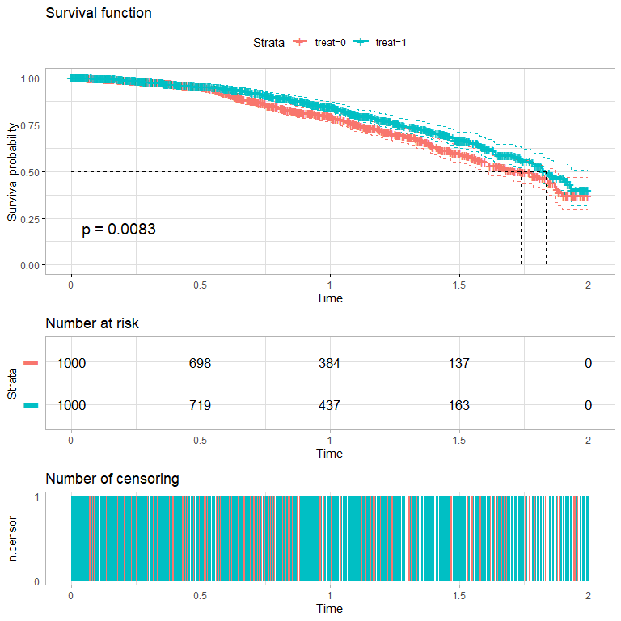

```r
sf.twogroups <- survfit(Surv(time=time,event=status)~treat, data)
ggsurvplot(
  sf.twogroups,            # survfit object with calculated statistics.
  data = data,             # data used to fit survival curves.
  risk.table = TRUE,       # show risk table.
  pval = TRUE,             # show p-value of log-rank test.
  conf.int = TRUE,         # show confidence intervals for point estimates of survival curves.
  xlab = "Time",   # customize X axis label.
  # break.time.by = 100,     # break X axis in time intervals by 500.
  ggtheme = theme_light(), # customize plot and risk table with a theme.
  risk.table.y.text.col = T,# colour risk table text annotations.
  risk.table.height = 0.25, # the height of the risk table
  risk.table.y.text = FALSE,# show bars instead of names in text annotations in legend of risk table.
  ncensor.plot = TRUE,      # plot the number of censored subjects at time t
  ncensor.plot.height = 0.25,
  conf.int.style = "step",  # customize style of confidence intervals
  surv.median.line = "hv",   # add the median survival pointer
  title    = "Survival function"
)
```

Estimation HR via Cox model:

```r
coxph(Surv(time, status) ~ treat, data)
```

```
#> Call:
#> coxph(formula = Surv(time, status) ~ treat, data = data)
#>
#>           coef exp(coef) se(coef)      z       p
#> treat -0.25131   0.77778  0.09541 -2.634 0.00844
#>
#> Likelihood ratio test=6.96  on 1 df, p=0.00834
#> n= 2000, number of events= 442
```

### Bivariate simulation (survival and binary data)

We simulate survival and binary data using copulas.

```r
library(copula)

set.seed(321)
# PARAMETERS
######################################
H0=FALSE
# H0=FALSE
a=0.5;b=1;tau0=0;tau=3;n0=1000; HR=0.65;n1=1000;
# tstar= 0.3
# p=0.2
# p: proportion of subjects who will survive beyond tstar
# tstar: treatment delayed duration since randomiation

p1=(1+22)/403
p0=0.1

# p1=0.01
# p0=0.05

######################################
# RE-PARAMETRIZATION for time-to-event simulation
lambda=(1/b)^a
rho=a

######################################
######################################


# Copula for binary and time-to-event
######################################
# Select the copula
cp <- claytonCopula(param = c(0.5), dim = 2)
# cp <- frankCopula(param = c(2), dim = 2)

# Generate the multivariate distribution with normal and t marginals
copulaSB <- mvdc(copula = cp,
                 margins = c("unif", "unif"),
                 paramMargins = list(list(0,1), list(0,1)))

# TREATMENT GROUP
######################################
v = rMvdc(n1,copulaSB)
BE0 = ifelse(v[,2]<p1, 1, 0)
TE0 = (-log(v[,1])/(lambda))^(1/rho)
# TE0 = TE0+tau0
# TC0 = rexp(n=n1, rate = 1)
TC0 = runif(n0, 0,tau)
time0= ifelse(TE0<=TC0, TE0, TC0)
status0 = ifelse(TE0<=TC0 & TE0<tau,1,0)
treat0 = rep(0,n0)
sim0 <- data.frame(BE0,time0,status0,treat0)

# CONTROL GROUP
######################################

v = rMvdc(n0,copulaSB)
if(H0==TRUE){

  BE1 = ifelse(v[,2]<p0, 1, 0)
  TE1 = (-log(v[,1])/(lambda))^(1/rho)
  # TE1 =TE1+tau0

}else{

  lambda=(1/b)^a
  rho=a

  TE1 <- (- log(v[,1])/(lambda*HR))^(1/rho)
  BE1 <-  ifelse(v[,2]<p0, 1, 0)

}

TC1 =  runif(n1, 0,tau)
time1 = ifelse(TE1<=TC1,TE1,TC1)
status1 = ifelse(TE1<=TC1 & TE1<tau,1,0)
treat1 = rep(1,n1)
sim1 <- data.frame(BE1,time1,status1,treat1)

# TWO-SAMPLE DATA
######################################
data = data.frame(binary=c(sim1$BE1, sim0$BE0), time=c(sim1$time1,sim0$time0), status=c(sim1$status1,sim0$status0),treat=c(sim1$treat1,sim0$treat0))

head(data)
```

```
#>   binary        time status treat
#> 1      0 0.002355762      1     1
#> 2      0 0.933375939      0     1
#> 3      0 0.390083267      1     1
#> 4      0 1.147913595      0     1
#> 5      0 0.097148660      0     1
#> 6      1 2.492500350      0     1
```

Kaplan-Meier curves:

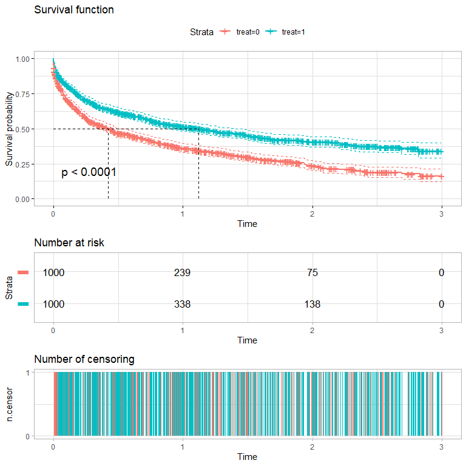

```r
sf.twogroups <- survfit(Surv(time=time,event=status)~treat, data)
ggsurvplot(
  sf.twogroups,            # survfit object with calculated statistics.
  data = data,             # data used to fit survival curves.
  risk.table = TRUE,       # show risk table.
  pval = TRUE,             # show p-value of log-rank test.
  conf.int = TRUE,         # show confidence intervals for point estimates of survival curves.
  xlab = "Time",   # customize X axis label.
  # break.time.by = 100,     # break X axis in time intervals by 500.
  ggtheme = theme_light(), # customize plot and risk table with a theme.
  risk.table.y.text.col = T,# colour risk table text annotations.
  risk.table.height = 0.25, # the height of the risk table
  risk.table.y.text = FALSE,# show bars instead of names in text annotations in legend of risk table.
  ncensor.plot = TRUE,      # plot the number of censored subjects at time t
  ncensor.plot.height = 0.25,
  conf.int.style = "step",  # customize style of confidence intervals
  surv.median.line = "hv",   # add the median survival pointer
  title    = "Survival function"
)
```

Without using a formula:

```r
sum(subset(data, data$treat==1)$binary)/n1
```

```
#> [1] 0.098
```

```r
sum(subset(data, data$treat==0)$binary)/n0
```

```
#> [1] 0.049
```

```r
coxph(Surv(time, status) ~ treat, data)
```

```
#> Call:
#> coxph(formula = Surv(time, status) ~ treat, data = data)
#>
#>           coef exp(coef) se(coef)      z        p
#> treat -0.45341   0.63546  0.05911 -7.671 1.71e-14
#>
#> Likelihood ratio test=59.5  on 1 df, p=1.223e-14
#> n= 2000, number of events= 1170
```

Using a formula:

```r
data=simsurvbin_H1(a.shape=a, b.scale=b, HR=0.75, rate.param=tau, p0=p0, p1=p1, ass.par=0.5, n0=500, n1=500, censoring="Unif", H0=FALSE)

sum(subset(data, data$treat==1)$binary)/n1
```

```
#> [1] 0.045
```

```r
sum(subset(data, data$treat==0)$binary)/n0
```

```
#> [1] 0.026
```

```r
coxph(Surv(time, status) ~ treat, data)
```

```
#> Call:
#> coxph(formula = Surv(time, status) ~ treat, data = data)
#>
#>           coef exp(coef) se(coef)      z        p
#> treat -0.31189   0.73206  0.08045 -3.877 0.000106
#>
#> Likelihood ratio test=15.1  on 1 df, p=0.0001018
#> n= 1000, number of events= 625
```

Kaplan-Meier curves:

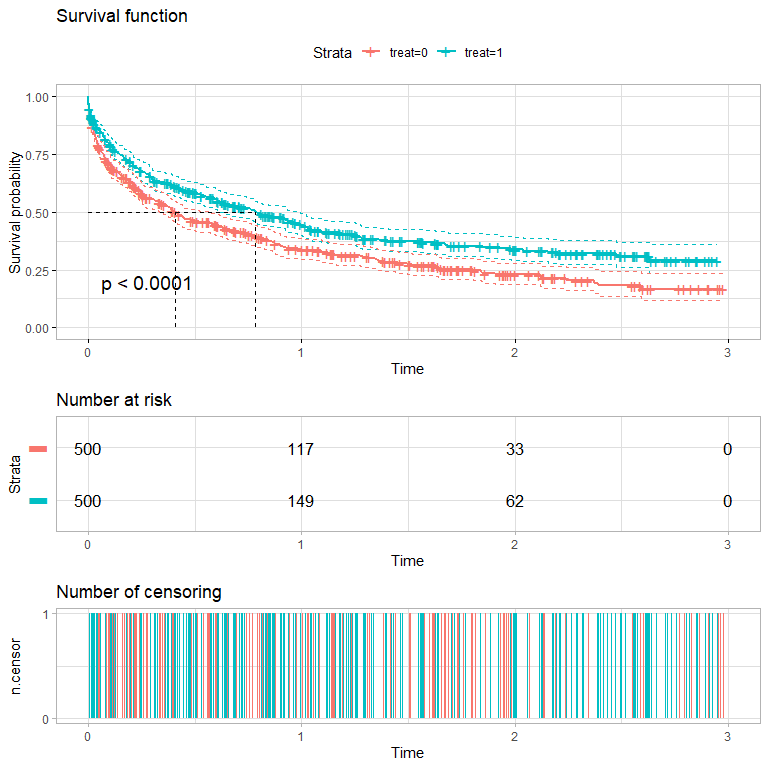

```r
sf.twogroups <- survfit(Surv(time=time,event=status)~treat, data)
ggsurvplot(
  sf.twogroups,            # survfit object with calculated statistics.
  data = data,             # data used to fit survival curves.
  risk.table = TRUE,       # show risk table.
  pval = TRUE,             # show p-value of log-rank test.
  conf.int = TRUE,         # show confidence intervals for point estimates of survival curves.
  xlab = "Time",   # customize X axis label.
  # break.time.by = 100,     # break X axis in time intervals by 500.
  ggtheme = theme_light(), # customize plot and risk table with a theme.
  risk.table.y.text.col = T,# colour risk table text annotations.
  risk.table.height = 0.25, # the height of the risk table
  risk.table.y.text = FALSE,# show bars instead of names in text annotations in legend of risk table.
  ncensor.plot = TRUE,      # plot the number of censored subjects at time t
  ncensor.plot.height = 0.25,
  conf.int.style = "step",  # customize style of confidence intervals
  surv.median.line = "hv",   # add the median survival pointer
  title    = "Survival function"
)
```

Scenarios Simulation:

```r
# Parameters
alpha=0.05;
z.alpha <- qnorm(1-alpha,0,1)
z.alphac <- qnorm(1-alpha/2,0,1)
nsim=1000
```

```r
power_plugin <- sum(replicate(nsim,fCS.TEST_H1(a.shape=a, b.scale=b, HR=0.80, rate.param=tau, p0=p0, p1=p1, ass.par=0.5,
                                               n0=500, n1=500, censoring="Unif",
                                               tau=2, taub=1, rho=1, gam=1, eta=1,
                                               wb=0.5, ws=0.5, var_est='Pooled')) > z.alpha,na.rm = T)/nsim

power_Bonf <- sum(replicate(nsim,(sum(fCS.TEST_Bonf_H1(a.shape=a, b.scale=b, HR=0.80, rate.param=tau, p0=p0, p1=p1, ass.par=0.5,
                                                       n0=500, n1=500, censoring="Unif",
                                                       tau=2, taub=1, rho=1, gam=1, eta=1)>z.alphac)>=1)))/nsim


power_boots <- sum(replicate(nsim,fCS.TEST_boots_H1(a.shape=a, b.scale=b, HR=0.80,
                                                     rate.param=tau, p0=p0, p1=p1, ass.par=0.5,
                                                     n0=500, n1=500, censoring="Unif",
                                                     tau=2, taub=1, rho=1, gam=1, eta=1,
                                                     wb=0.5, ws=0.5)) > z.alpha,na.rm = T)/nsim

(power_plugin)
```

```
#> [1] 0.958
```

```r
(power_Bonf)
```

```
#> [1] 0.914
```

```r
(power_boots)
```

```
#> [1] 0.957
```

## Under non-PH model

Then, in order to simulate delayed effects until $t_*$, we calculate for which values of the uniform we obtain times larger (smaller) than $t_*$.

- If $T>t_*$, then: $U<e^{-(1/b)^a t_*^a }$
- If $T<t_*$, then: $U>e^{-(1/b)^a t_*^a }$

So that, we simulate $n_1 \cdot p$ subjects according to:
$$T_1 \sim \left( -\frac{\log(U)}{(1/b)^a} \right)^{1/a}$$
where $U\sim Uniform (e^{-(1/b)^a t_*^a },1)$. While we simulate $n_1 \cdot (1-p)$ subjects using:
$$T_1 \sim \left( -\frac{\log(U)}{(1/b)^a*HR} \right)^{1/a}$$
where $U\sim Uniform (0,e^{-(1/b)^a t_*^a })$.